# 第4回 物差しを選び、係数を説明に変える

MAE・RMSE・対数・交差検証。そして、この家はなぜこの値段か

# 導入

## 前回の宿題

- 外れ幅の平均だけで、式を選んでよいのか
- 高い部屋を外して、よかったのか

## もう1つの宿題

- 式がどれだけ当たるかは、測れるようになった
- でも、式の中身は、まだ一度も読んでいない

## 場面が変わる

- あなたは、住宅の査定担当者
- 米国エイムズ市の、約2,400軒の住宅の売買価格

## 今日の問い

「この家は、なぜこの値段なのか」を説明する式を、どの物差しで選び、どう読むか。

## 今日のコードの書き方

- 物差しを関数にして、`for`文の中で何度も呼ぶ
- 結果を辞書にためて、表にまとめる
- f-stringで、数を文の中に埋め込む

## この問いに、どう近づくか

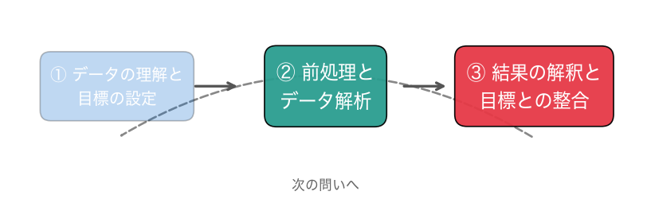

②の評価と、③の解釈が中心です。

# 0. 設定

## やってみよう：0節

- 第4回のノートを開き、ドライブにコピーする
- 0節の設定のセルを実行し、「セットアップ完了」を確かめる

動画の人は、ここで一時停止。

# 1. どの売買を手がかりにするか

## まず、手がかりにする売買を決める

- 第3回の民泊でも、最初に、使う部屋を目標から決めた
- 今日も、査定の手がかりにする売買を先に選ぶ

## 売買の条件が、混ざっている

- ふつうの売買のほかに、建築中・差し押さえ・家族間の売買
- 査定で説明したいのは、ふつうの売買の値段

## 極端に広い家も、外す

- 居住面積が4,000平方フィート（約372㎡）超の家は、全体で5軒だけ
- ほかの家とは、値段の付き方が違う
- データの作者も、授業で使うなら外すよう勧めている

## お手本：ふつうの売買に絞る

```python
raw = pd.read_csv(f'{DATA_DIR}/ames_housing.csv')
normal = raw['Sale Condition'] == 'Normal'         # ふつうの売買
small = raw['Gr Liv Area'] <= 4000                 # 広すぎない家
df = raw[normal & small].reset_index(drop=True)
for c in ['Gr Liv Area', 'Total Bsmt SF', 'Garage Area', 'Lot Area']:
    df[c] = df[c] * 0.0929                         # 平方フィート → ㎡
print(len(df), '軒')
print(df['SalePrice'].describe().round(0))
```

- 役割：ふつうの売買で、広すぎない家に絞り、面積を㎡に直す

## 変えてみる：11本の列で線形回帰

```python
feat = ['Overall Qual', 'Gr Liv Area', 'Total Bsmt SF', 'Garage Cars',
        'Garage Area', 'Year Built', 'Year Remod/Add', 'Full Bath',
        'TotRms AbvGrd', 'Fireplaces', 'Lot Area']
tr, te = train_test_split(df, test_size=0.2, random_state=42)
X_tr, X_te = tr[feat], te[feat]
y_tr, y_te = tr['SalePrice'].values, te['SalePrice'].values
m = LinearRegression().fit(X_tr, y_tr)
print(m.score(X_te, y_te))                         # テストの R²
```

## やってみよう：1節

- 1節のお手本と「変えてみる」のセルを実行する
- テストのR²は、いくつか？

動画の人は、ここで一時停止。

## 答え合わせ：2,412軒

```
2412 軒
count      2412.0
mean     175327.0
std       70006.0
min       35000.0
25%      129500.0
50%      158750.0
75%      206225.0
max      625000.0
```

- ふつうの売買で広すぎない家は2,412軒。価格の中央値は約16万ドル

## 答え合わせ：R²は0.867

```
0.8671871477417941
```

- よく当たる式に見える。では、何ドルくらい外れるのか？

# 2. 物差しを、関数にする

## R²は高い。では、何ドル外れる？

- テストのR²は0.867。よく当たる式に見える
- 査定では、外れをドルで知りたい

## おさらい：def

```python
def 名前(引数):
    return 戻り値
```

- `def`の後ろが名前と引数（入力）、`return`の後ろが戻り値（出力）（第3回）
- `名前(値)`で呼び出す

## お手本：外れ幅の平均（MAE）

```python
def mae(y, pred):          # 外れ幅の平均（MAE）
    return round(np.abs(y - pred).mean())

print(mae(y_te, np.median(y_tr)))       # 基準：どの家も中央値と答える
print(mae(y_te, m.predict(X_te)))       # 線形回帰
```

- 役割：実際の価格と予測から、外れ幅の平均を出す

## MAEは、大外れを見分けない

- 1万ドルの外れが10回でも
- 10万ドルの外れが1回と、9回の当たりでも、同じ値になる
- 査定で10万ドル外すのは、大きな失敗

## RMSE：大外れを重く見る

- 外れを二乗して平均し、最後にルートを取る
- 二乗するので、大外れが重く数えられる
- ルートで、ドルの単位に戻る

## 変えてみる：RMSEを関数にする

```python
def rmse(y, pred):        # 二乗して平均し、ルートを取る
    return round(np.sqrt(((y - pred) ** 2).mean()))

print(rmse(y_te, m.predict(X_te)))
mse = mean_squared_error(y_te, m.predict(X_te))
print(round(np.sqrt(mse)))                 # 答え合わせ
```

- `mae`の中身を、「二乗 → 平均 → ルート」に変えるだけ
- `mean_squared_error`は、scikit-learnの二乗の平均（MSE）

## TODO①：大外れの割合

```python
# TODO: 外れの二乗 err2 を大きい順に並べ、
#       上位5%の合計が全体の何割かを表示する
# ヒント: err2 = (y_te - m.predict(X_te)) ** 2 のあと、
#         np.sort(err2)[::-1] で大きい順に並ぶ
...
```

- 上位5%は`len(err2) // 20`軒。`//`は、割り算の整数の部分

## やってみよう：2節とTODO①

- 2節のお手本と「変えてみる」のセルを実行する
- TODO①：上位5%の大外れが、二乗の合計の何割かを出す

動画の人は、ここで一時停止。

## 答え合わせ：MAE

```
50318
19061
```

- 基準は50,318ドル、線形回帰は19,061ドル
- 線形回帰の外れ幅は、基準の半分以下

## 答え合わせ：RMSE

```
25627
```

- RMSEは25,627ドル。MAE（19,061ドル）より大きい

## RMSEは、いつもMAE以上

- 差が大きいほど、大外れが混ざっている
- では、どのくらいの大外れが混ざっているのか？

## 1軒ごとの外れを見ると

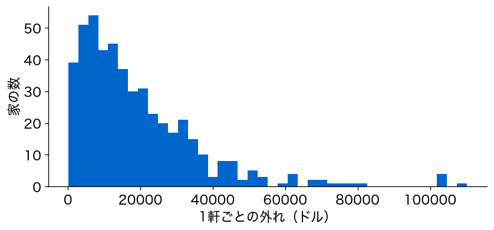

- ほとんどは数万ドル以内。でも、右に長い尾がある

## 答え合わせ：TODO①

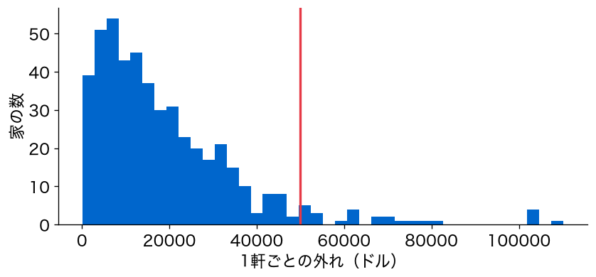

- 赤線より右の上位5%（24軒）だけで、外れの二乗の合計の4割（0.417）

# 3. 高い家に、引っぱられていないか

## 大外れが4割。どんな家で外す？

- 上位5%の家だけで、外れの二乗の合計の4割
- その大外れは、どんな家で起きているのか

## 価格の形は？

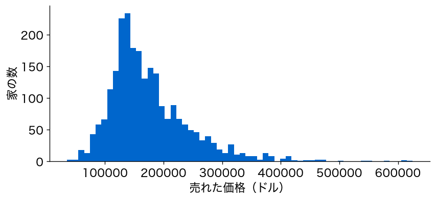

## 右に長く歪んでいる

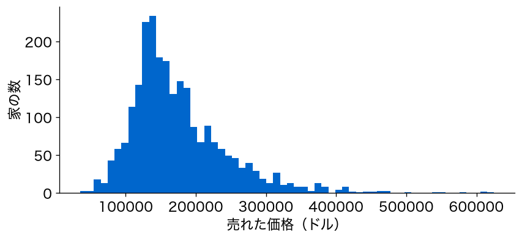

- 第3回の民泊の料金と同じ形

## 高い家だけ、外れを測る

```python
pred_raw = m.predict(X_te)                 # そのまま当てた予測
high = y_te > 300000                       # 30万ドルを超える家
print(high.sum(), '軒')
print(mae(y_te[high], pred_raw[high]))     # 高い家の外れ幅の平均
print(pred_raw.min().round(0))             # いちばん安い予測
```

- `y_te[high]`で、`high`がTrueの家だけを取り出す

## 高い家で、大きく外す

```
30 軒
52197
-3296.0
```

- 30万ドル超の30軒では、外れ幅の平均が52,197ドル（全体は19,061）

## ありえない価格も出た

```
30 軒
52197
-3296.0
```

- ある家に−3,296ドルという、ありえない価格を付けた

## 対数を当てる

- 価格そのものではなく、価格の対数（`np.log`）を当てる
- 10万→20万ドルと、20万→40万ドルが、同じ幅になる
- 当てたあと`np.exp`で戻せば、ドルで、必ずプラス

## お手本：対数を当てて戻す

```python
m_log = LinearRegression().fit(X_tr, np.log(y_tr))   # 対数を当てる
pred_log = np.exp(m_log.predict(X_te))             # ドルに戻す
print(pred_log[:3].round(0))
print(pred_log.min().round(0))                     # いちばん安い予測
```

- 役割：対数を当てる線形回帰を立て、予測をドルに戻す

## TODO②：2つの式を比べる

```python
# TODO: 2つの式の MAE と RMSE を表示する
# ヒント: mae(y_te, pred_log) と rmse(y_te, pred_log)。
#         そのまま当てた式も同じように
...
```

- 関数にしてあるので、呼ぶだけで比べられる

## やってみよう：3節とTODO②

- 3節のお手本のセルを実行する
- TODO②：2つの式の、MAEとRMSEを出す

動画の人は、ここで一時停止。

## 答え合わせ：いちばん安い予測

```
[112987. 116576. 175783.]
63130.0
```

- 対数の式のいちばん安い予測は63,130ドル。マイナスは出ない

## 答え合わせ：MAEでは？

```
そのまま: MAE 19061  RMSE 25627
対数    : MAE 16408  RMSE 26296
```

- MAEでは、対数16,408ドル。そのまま（19,061ドル）より良い

## RMSEでは？

```
そのまま: MAE 19061  RMSE 25627
対数    : MAE 16408  RMSE 26296
```

- RMSEでは、対数26,296ドル。そのまま（25,627ドル）より悪い

## 物差しで、順位が入れ替わった

- MAEなら対数、RMSEならそのまま
- どちらを信じればよいのか？ その前に、確かめることがある

# 4. 1回の分け方で、決めてよいか

## TODO② は、1回の分け方

- `random_state=42`の、1回の分け方の結果
- 第2回で見たとおり、1回の値は運で動く

## おさらい：for文

```python
for i in range(3):
    print(i)          # 0, 1, 2 と表示される
```

- 並びの中身を1つずつ名前に入れながら、字下げした行を繰り返す（第2回）

## kf.split：5回ぶんの分け方

```python
kf = KFold(n_splits=5, shuffle=True, random_state=42)
for a, b in kf.split(df):
    print(len(a), len(b), a[:3])     # 訓練の数・テストの数・行番号
```

- `kf.split(df)`は、（訓練の行番号, テストの行番号）の組を順に出す

## 1回ごとに、行番号の組が1つ

```
1929 483 [0 1 2]
1929 483 [0 1 3]
1930 482 [0 1 2]
1930 482 [1 2 3]
1930 482 [0 2 3]
```

- `for a, b in`で、組をaとbに分けて受け取る
- 5回で、どの家もちょうど1回テストに回る

## enumerate：番号を付けて回す

```python
for k, w in enumerate(['A', 'B', 'C']):
    print(k, w)          # 0 A、1 B、2 C と表示される
```

- 中身に0から番号を付けて、（番号, 中身）の組で出す
- 何回目かを数えながら回したいときに使う

## お手本：5回まわして、表に

```python
rows = []
for k, (a, b) in enumerate(kf.split(df)):
    t, s = df.iloc[a], df.iloc[b]      # その回の訓練とテスト
    m1 = LinearRegression().fit(t[feat], t['SalePrice'])
    p1 = m1.predict(s[feat])
    rows.append({'回': k + 1,
                 'MAE_そのまま': mae(s['SalePrice'], p1),
                 'RMSE_そのまま': rmse(s['SalePrice'], p1)})
table = pd.DataFrame(rows)
print(table)
```

## 1行目：番号と、分け方の組

```python
for k, (a, b) in enumerate(kf.split(df)):
```

- `enumerate`と`kf.split`を合わせた形
- `k`が回の番号（0から）。`(a, b)`が分け方の組

## iloc：行番号で取り出す

```python
    t, s = df.iloc[a], df.iloc[b]      # その回の訓練とテスト
```

- `iloc`は、行番号（0から数えた位置）で行を取り出す
- `a`の行が訓練`t`、`b`の行がテスト`s`

## 関数を、for文の中で呼ぶ

```python
    rows.append({'回': k + 1,
                 'MAE_そのまま': mae(s['SalePrice'], p1),
                 'RMSE_そのまま': rmse(s['SalePrice'], p1)})
```

- 2節で作った`mae`・`rmse`を、各回で呼んでいる
- 小さな関数を組み合わせて、交差検証を作る

## 辞書をためて、表にする

```python
rows = []
for k, (a, b) in enumerate(kf.split(df)):
    ...
    rows.append({'回': k + 1,
    ...
table = pd.DataFrame(rows)
```

- 各回の結果を辞書（`{'名前': 値}`）にして、リスト`rows`にためる
- `pd.DataFrame(rows)`で、辞書1つが1行の表になる

## TODO③：対数の式も並べる

```python
# TODO: お手本の for 文の中に、対数の式の予測 p2 を足し、
#       'MAE_対数' と 'RMSE_対数' を辞書に加えて、表と平均を表示する
...
```

- ヒント：`p2`の作り方は、3節のお手本と同じ

## やってみよう：4節とTODO③

- 4節のお手本のセルを実行する
- TODO③：対数の式も表に並べ、列ごとの平均を出す

動画の人は、ここで一時停止。

## 答え合わせ：TODO③ の表

```
 回  MAE_そのまま  RMSE_そのまま  MAE_対数  RMSE_対数
 1     19061      25627   16408    26296
 2     18708      26332   15292    20660
 3     19785      29005   16024    22202
 4     19462      27000   16509    22350
 5     19504      27058   16245    22006
```

- 5回それぞれの、2つの式のMAEとRMSE

## 平均で見ると

```
MAE_そのまま     19304.0
RMSE_そのまま    27004.0
MAE_対数       16096.0
RMSE_対数      22703.0
```

- MAEもRMSEも、対数の式のほうが良い

## 逆転は、1回目だけ

```
 回  MAE_そのまま  RMSE_そのまま  MAE_対数  RMSE_対数
 1     19061      25627   16408    26296
 2     18708      26332   15292    20660
 3     19785      29005   16024    22202
 4     19462      27000   16509    22350
 5     19504      27058   16245    22006
```

- RMSEで対数が負けたのは、1回目の分け方だけ

## 1回目は、TODO② と同じ分け方

```
 回  MAE_そのまま  RMSE_そのまま  MAE_対数  RMSE_対数
 1     19061      25627   16408    26296
 2     18708      26332   15292    20660
 3     19785      29005   16024    22202
 4     19462      27000   16509    22350
 5     19504      27058   16245    22006
```

- 1回目のテストの483軒は、TODO② のテストと同じ家
- TODO② の逆転は、その分け方でたまたま起きた

## 物差しを決めてから、選ぶ

物差しを決め、交差検証の平均で比べてから、式を選ぶ。

## 査定担当の選択

- 高い家でも大外れしにくく、マイナスの価格も出さない
- 当てる式には、対数の式を選ぶ

# 5. 係数を読む

## でも、説明はどうする？

- 対数の式の係数は、「1単位増えると価格が何%変わるか」と読む
- 少し、ややこしい
- ここからは、係数がドルで読める、そのままの式で説明を考える

## 係数は、1単位あたりの変化

```python
coef = pd.Series(m.coef_, index=feat)
print(coef.round(1))
```

- それぞれの列が1単位増えたとき、予測価格が何ドル変わるか

## お手本：係数を文にする

```python
area = coef['Gr Liv Area']
print(f'居住面積が1㎡広いと、ほかの条件をそろえたうえで、'
      f'価格は約{area:,.0f}ドル高い')
```

- 役割：居住面積の係数を、日本語の文に埋め込んで表示する

## f-stringの読み方

```python
      f'価格は約{area:,.0f}ドル高い')
```

- 文字列の前に`f`を付けると、`{ }`の中の値が埋め込まれる
- `:,.0f`は「3けたごとにカンマ、小数点以下0けた」という書式

## 変えてみる：品質の係数も文に

```python
qual = coef['Overall Qual']
print(f'品質が1段階高いと、ほかの条件をそろえたうえで、'
      f'価格は約{qual:,.0f}ドル高い')
```

- 埋め込む値と、文の言葉を変えるだけ

## やってみよう：5節

- 5節のお手本と「変えてみる」のセルを実行する
- 1㎡広いと、何ドル高い？

動画の人は、ここで一時停止。

## 答え合わせ：677ドル

```
居住面積が1㎡広いと、ほかの条件をそろえたうえで、価格は約677ドル高い
品質が1段階高いと、ほかの条件をそろえたうえで、価格は約15,968ドル高い
```

- 1㎡あたり約677ドル、品質1段階あたり約15,968ドル

## 「ほかの条件をそろえたうえで」

- 677ドルは、品質も、建てた年も、部屋の数も同じ家どうしの差
- この一言を落とすと、広い家が品質も新しさも違うぶんまで、面積のおかげになる

# 6. おかしな符号と、大きさの比べ方

## 係数は文になった。ほかの列は？

- 5節で、面積と品質の係数を文にした
- ほかの列の係数も、そのまま読めるか

## お風呂が多いと、安い？

```
Full Bath       -8610.0
TotRms AbvGrd   -2911.0
Garage Cars      -312.0
```

- バスルーム−8,610ドル、部屋の数−2,911ドル、車庫の台数−312ドル

## お手本：バスルームだけの式

```python
m_bath = LinearRegression().fit(tr[['Full Bath']], y_tr)
print(f"バスルームだけの式: 1つ多いと {m_bath.coef_[0]:+,.0f} ドル")
print(f"11本の列の式      : 1つ多いと {coef['Full Bath']:+,.0f} ドル")
cols3 = ['Full Bath', 'Gr Liv Area', 'TotRms AbvGrd']
print(tr[cols3].corr().round(2))
```

- `:+,.0f`の`+`は、プラスのときも符号を付ける書式

## 変えてみる：標準化した係数

```python
sc = StandardScaler().fit(X_tr)                    # 物差しは訓練で
m_std = LinearRegression().fit(sc.transform(X_tr), y_tr)
coef_std = pd.Series(m_std.coef_, index=feat)
print(coef_std.sort_values(key=abs, ascending=False).round(0))
```

- `key=abs`で、絶対値の大きい順に並べる

## 変えてみる：車庫の面積を外す

```python
print(tr['Garage Cars'].corr(tr['Garage Area']).round(2))
feat_no_area = [f for f in feat if f != 'Garage Area']   # 面積を外す
m_no_area = LinearRegression().fit(tr[feat_no_area], y_tr)
cars = m_no_area.coef_[feat_no_area.index('Garage Cars')]
print(f'車庫の面積を外すと、台数の係数は {cars:+,.0f} ドル')
print(mae(y_te, m_no_area.predict(te[feat_no_area])))
```

## やってみよう：6節

- 6節のお手本と、2つの「変えてみる」のセルを実行する
- バスルームの係数は、なぜマイナスになったのか？

動画の人は、ここで一時停止。

## 答え合わせ：バスルームだけなら

```
バスルームだけの式: 1つ多いと +71,941 ドル
11本の列の式      : 1つ多いと -8,610 ドル
```

- バスルームだけの式では、+71,941ドル
- 11本の式では、−8,610ドル

## バスルームが多い家は、広い

```
               Full Bath  Gr Liv Area  TotRms AbvGrd
Full Bath           1.00         0.65           0.55
Gr Liv Area         0.65         1.00           0.81
TotRms AbvGrd       0.55         0.81           1.00
```

- 居住面積との相関は0.65。広さの影響は、面積の係数が受け持つ

## 同じ広さなら、ほかの部屋が狭い

- 11本の式のバスルームの係数は、「同じ広さなら、バスルームが1つ多い家」の差
- そのぶん、ほかの部屋が狭くなりがち
- マイナスは、その差を表していると考えられる

## 符号は、一緒に入れた列で変わる

係数の符号は、どの列を一緒に入れたかで変わる。単独の関係とは別もの。

## 価格にいちばん関わる列は？

- 品質の15,968ドルは「1段階」あたり、面積の677ドルは「1㎡」あたり
- 単位が違うので、そのままでは比べられない

## 答え合わせ：標準化した係数

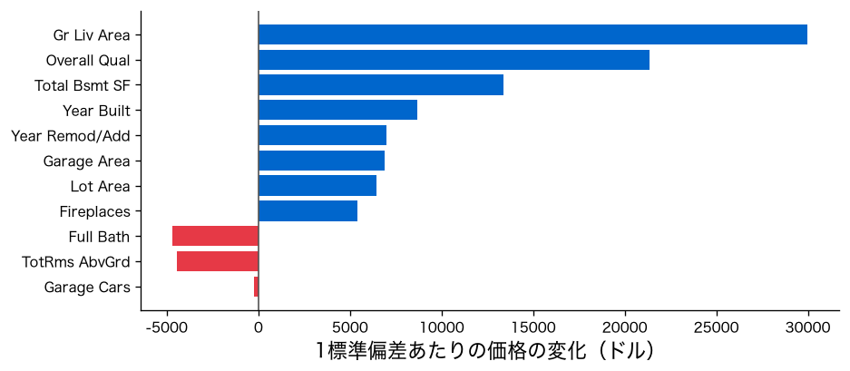

- 1標準偏差あたりで比べる。いちばん上が、価格にいちばん大きく関わる列

## 面積と品質が、上位

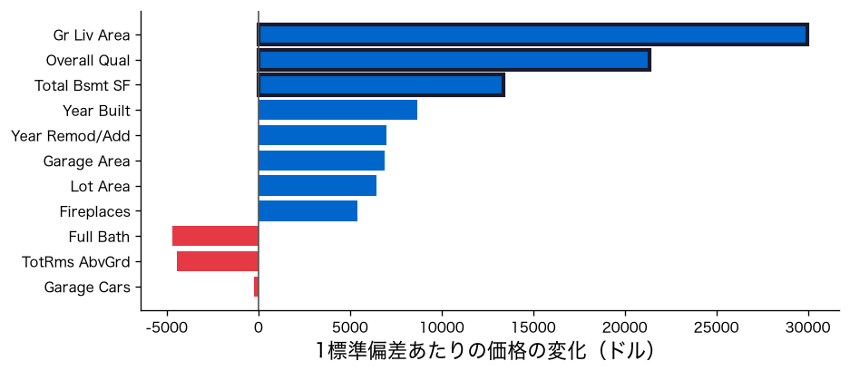

- 居住面積29,984ドル、品質21,338ドル、地下室13,379ドル

## 車庫の台数は、ほぼゼロ

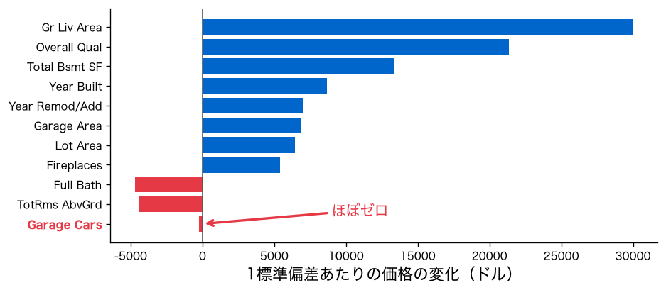

- 車庫の台数は−227ドル。なぜか？

## 答え合わせ：車庫の面積を外すと

```
0.88
車庫の面積を外すと、台数の係数は +7,725 ドル
19373
```

- 台数と面積の相関は、0.88
- 面積を外すと、台数の係数は+7,725ドル
- 外れ幅は、ほぼ同じ

## 分け前が、決まらない

- 台数と面積は、ほぼ同じ情報を持つ
- どちらの係数で受け持っても、当たり具合は同じ。だから係数が揺れる

## 似た列の組は、合わせて読む

- これを多重共線性と呼ぶ
- 似た列の組は、係数を1つずつ読まず、合わせて読む

# 7. この家は、なぜこの値段なのか

## 係数は読めた。1軒の値段は？

- 6節までは、列ごとに係数を読んだ
- 次は、1軒の家で読む。「この家は、なぜこの値段なのか」

## 予測を、条件ごとに分ける

- 予測価格 ＝ 訓練の平均価格 ＋ Σ（係数 ×（その家の値 − 平均の値））
- 「係数 ×（その家の値 − 平均）」が、その条件による押し上げ

## 査定書は、説明用の式で

- 押し上げがドルの足し算になるのは、そのままの式
- 査定書の予測も押し上げも、そのままの式のもの
- 当てる式（対数）の予測とは、少しずれる

## お手本：査定書を作る

```python
house = te.iloc[[0]]
contrib = (house[feat].iloc[0] - X_tr.mean()) * coef   # 押し上げ
contrib = contrib.sort_values(key=abs, ascending=False)
print(contrib.round(0).head(4))
pred = m.predict(house[feat])[0]
print(f'予測 {pred:,.0f} ドル（平均的な家 {y_tr.mean():,.0f} ドル）')
print(f'理由: {contrib.index[0]} で {contrib.iloc[0]:+,.0f} ドル、'
      f'{contrib.index[1]} で {contrib.iloc[1]:+,.0f} ドル')
```

## TODO④：別の家の査定書

```python
# TODO: 別の家を選び、お手本と同じく押し上げを計算して、
#       査定書の文を表示する
# ヒント: house = te.iloc[[0]] の 0 を 5 などに変え、
#         残りの行はそのまま使える
...
```

## やってみよう：7節とTODO④

- 7節のお手本のセルを実行する
- TODO④：別の家を選んで、査定書の文を出す

動画の人は、ここで一時停止。

## 答え合わせ：108,700ドル

```
予測 108,700 ドル（平均的な家 175,807 ドル）
理由: Gr Liv Area で -29,728 ドル、Overall Qual で -16,158 ドル
```

- そのままの式で、平均的な家より約6万7千ドル安い（実際は131,000ドル）

## 押し上げの内訳

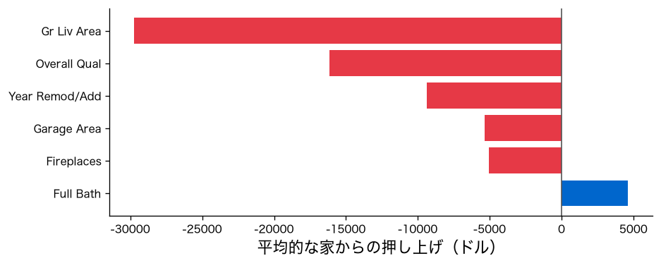

- 左に伸びるほど、平均より押し下げ

## 狭さと、品質

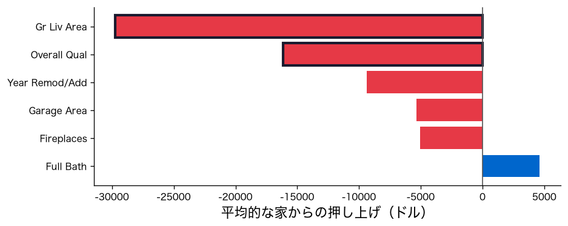

- 居住面積が狭い（約94㎡）ことで、−29,728ドル
- 品質が5段階であることで、−16,158ドル

## 査定担当の答え

この家が平均より安いのは、主に、狭さ（約3万ドル）と品質（約1万6千ドル）のため。

## 答え合わせ：TODO④ の例

```
予測 177,943 ドル（平均的な家 175,807 ドル）
理由: Total Bsmt SF で +23,143 ドル、Overall Qual で -16,158 ドル
```

- 6番目の家は、地下室の広さで押し上げ、品質で押し下げ

## まだ言えないこと①：揺れる係数

- 車庫の台数と面積のように、揺れる係数をどう落ち着かせるか

## まだ言えないこと②：列の選び方

- 今日は80本のうち11本を選んだ
- 残りの列を入れると、係数はどうなるか

# まとめ

## 今日の歩み

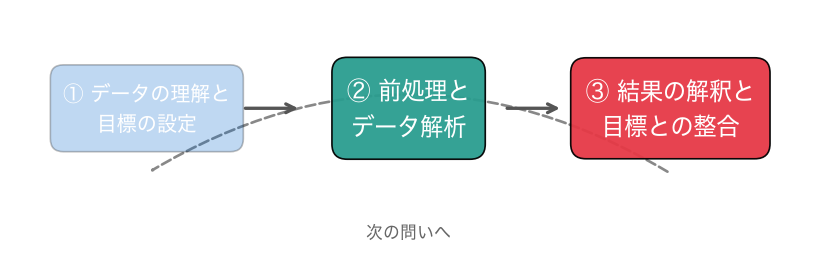

物差しを関数に → 対数で当てる → 交差検証で選ぶ → 係数を読む → 査定書

## 今日の要点

- RMSEは大外れを重く見る。大外れが混ざるとMAEより大きくなる
- 歪んだ価格は、対数を当ててから戻す
- 物差しで順位は入れ替わる。交差検証の平均で比べてから選ぶ
- 係数は「ほかの条件をそろえたうえで」の変化。似た列の組は合わせて読む
- Python：関数を`for`の中で呼び、辞書を表に。f-stringで文に

## 課題の出し方

- ノートの最後の「課題（提出）」に取り組む
- 応用②の答えと応用③の文章を、LACSに入力して提出（＝出席。期限なし）
- AIを使ってもよい。何を聞いて、どう直したかを1行書く

## 次回予告：係数を抑える

- 列を35本に増やす
- 当たりは良くなるのに、係数はもっとおかしくなる

## 次回の問い

列を増やして当たりを良くしながら、お客さんに説明できる係数を保てるか？

## このあと：課題へ

ノートの「課題（提出）」へ。車庫の台数を外して、車庫の影響を読み直します。